# ReproResearch

Balaji K

4 January 2018

## R Markdown

1. Set working directory
2. Clone the github repository to local from R-Studio, using the shell command - git clone
3. Unzip the input file and read (tried reading compressed file directly using readr, but it didn’t help)
4. Include dplyr package for data manipulations
5. Load the data into a tbl_df and arrange columns, group by and summarize
6. Now, get answer for Q1 - What is mean total number of steps taken per day?

Loading and preprocessing the data

```r
mywd <- setwd("~/R/03. R Projects/Coursera projects/Reproducible Research/Course Project 1")
mySrcData <- "/home/balman/R/03. R Projects/Coursera projects/Reproducible Research/Course Project 1/RepData_PeerAssessment1"
setwd(mySrcData)
myRawData <- read.csv("activity.csv")
library(dplyr)
my_tib1 <- tbl_df(myRawData)
my_tib2 <- select(.data = my_tib1, 2:3, 1)
by_date <- group_by(my_tib2, date)
by_date_sum <- summarise(by_date, steps_tot = sum(steps,na.rm = TRUE))
summary(by_date_sum)
```

```
##          date      steps_tot
##  2012-10-01: 1   Min.   :    0
##  2012-10-02: 1   1st Qu.: 6778
##  2012-10-03: 1   Median :10395
##  2012-10-04: 1   Mean   : 9354
##  2012-10-05: 1   3rd Qu.:12811
##  2012-10-06: 1   Max.   :21194
##  (Other)   :55
```

# 2. Plot the histogram on Daily steps count

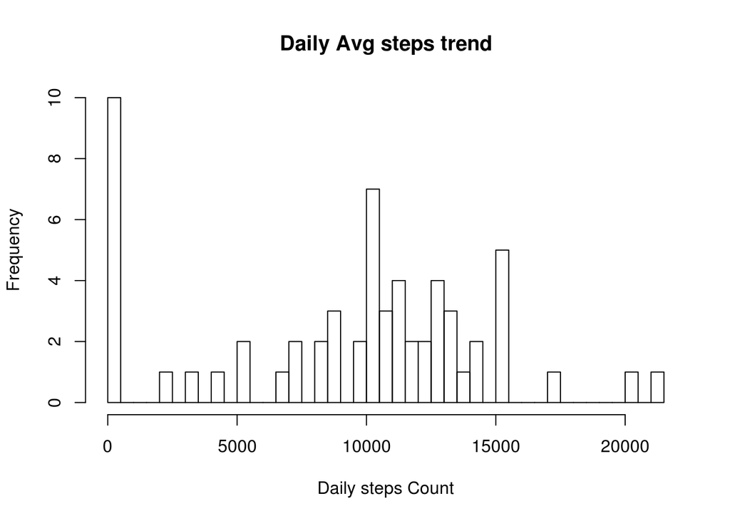

```r
hist(x = by_date_sum$steps_tot, main = "Daily Avg steps trend", xlab = "Daily steps Count",breaks = 61)
```

```r
#png("plot1.png", width=480, height=480)
#with(by_date_sum, {
#  hist(x = by_date_sum$steps_tot, main = "Daily Avg steps trend", xlab = "Daily steps Count",breaks = 61)
#})
#dev.off()
```

# 3. Code to calculate Mean and median number of steps taken each day

```r
mean_steps_per_day <- mean(by_date_sum$steps_tot)
median_steps_per_day <- median(by_date_sum$steps_tot)
 mean_steps_per_day
```

```
## [1] 9354.23
```

```r
 median_steps_per_day
```

```
## [1] 10395
```

# 4. Time series plot of the average number of steps taken

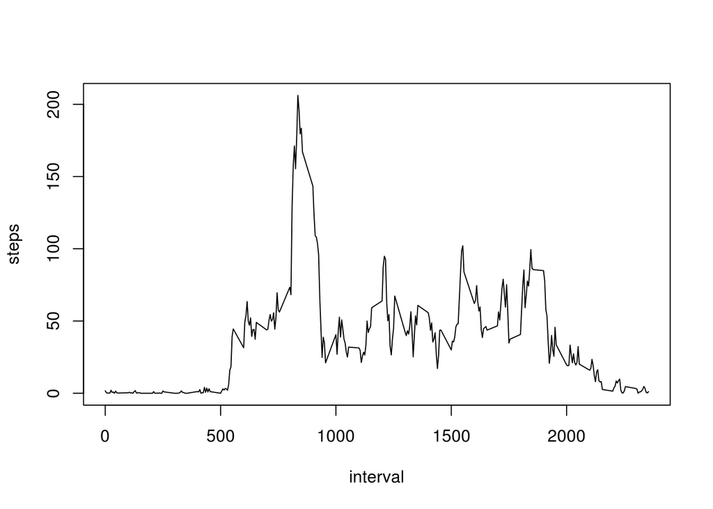

```r
by_date_avg <- summarise(by_date, steps_avg = mean(steps,na.rm = TRUE))
    plot(aggregate(steps ~ interval, data = by_date, FUN = mean), type = "l")
```

```r
#png("plot2.png", width=480, height=480)
#with(by_date, {
#    plot(aggregate(steps ~ interval, data = by_date, FUN = mean), type = "l")
#})
#dev.off()
```

# The 5-minute interval that, on average, contains the maximum number of steps

```r
by_interval <- group_by(my_tib2, interval)
by_interval_sum <- summarise(by_interval, max_steps = max(steps, na.rm = TRUE))
arrange(by_interval_sum, desc(max_steps))
```

```
## # A tibble: 288 x 2
##    interval max_steps
##       <int>     <dbl>
##  1      615       806
##  2      900       802
##  3      550       794
##  4      720       789
##  5      835       786
##  6      925       785
##  7     1600       785
##  8     1635       785
##  9     1140       783
## 10      850       781
## # ... with 278 more rows
```

```r
max_steps <- max(by_interval_sum$max_steps)
filter(by_interval_sum, max_steps == 806)
```

```
## # A tibble: 1 x 2
##   interval max_steps
##      <int>     <dbl>
## 1      615       806
```

Code to describe and show a strategy for imputing missing data Replaced NAs with mean value of steps

```r
by_date_cleaned <- by_date
by_date_cleaned$steps[is.na(by_date_cleaned$steps)] <- mean(na.omit(by_date_cleaned$steps))
```

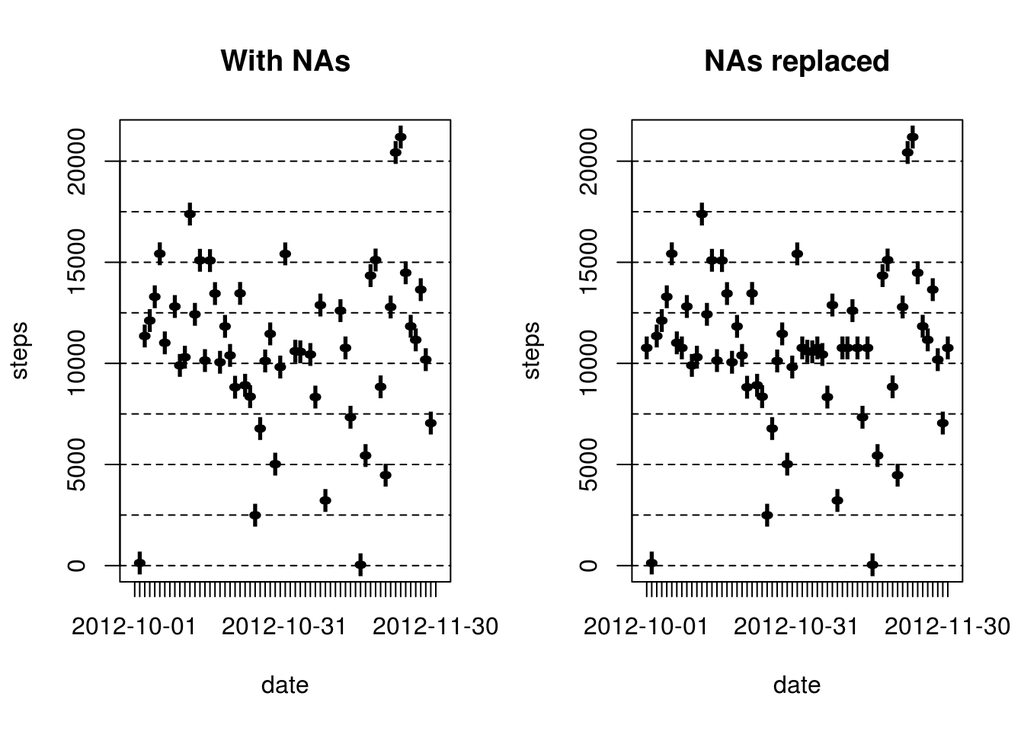

```r
by_date_sum <- aggregate(steps ~ date, rm.na = TRUE, data = by_date, FUN = sum)
by_date_sum2 <- aggregate(steps ~ date, rm.na = TRUE, data = by_date_cleaned, FUN = sum)

with(by_date_sum, {
par(mfrow = c(1, 2))
plot(by_date_sum, type = "h", lwd = 5,lend = "square", main = "With NAs")
abline(h = seq(0, 20000, 2500), lty = "dashed")
plot(by_date_sum2, type = "h", lwd = 5, lend = "square", main = "NAs replaced")
abline(h = seq(0, 20000, 2500), lty = "dashed")
})
```

```r
#png("plot3.png", width=480, height=480)
#with(by_date_sum, {
#par(mfrow = c(1, 2))
#plot(by_date_sum, type = "h", lwd = 5,lend = "square", main = "With NAs")
#abline(h = seq(0, 20000, 2500), lty = "dashed")
#plot(by_date_sum2, type = "h", lwd = 5, lend = "square", main = "NAs replaced")
#abline(h = seq(0, 20000, 2500), lty = "dashed")
#})
#dev.off()

mean_by_date <- aggregate(steps ~ date, data = by_date, FUN = mean)
mean_by_date_cleaned <- aggregate(steps ~ date, data = by_date_cleaned, FUN = mean)
median_by_date <- aggregate(steps ~ date, data = by_date, FUN = median)
median_by_date_cleaned <- aggregate(steps ~ date, data = by_date_cleaned, FUN = median)
```

Are there differences in activity patterns between weekdays and weekends?

```r
by_date_cleaned$date <- as.POSIXct(by_date_cleaned$date)
by_date_cleaned$daytype <-  ifelse(weekdays(by_date_cleaned$date) %in% c("Saturday", "Sunday"), "weekend", "weekday")
by_date_cleaned$daytype <- as.factor(by_date_cleaned$daytype)
```

Plotting the timeseries plots

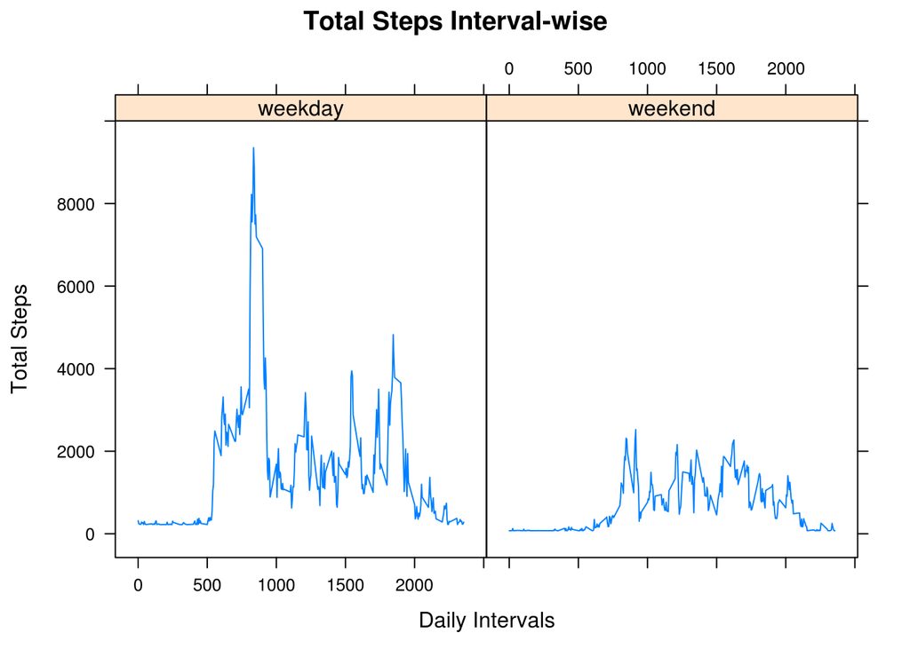

```r
q <- by_date_cleaned %>% group_by(daytype, interval) %>% summarize(daily_steps_tot = sum(steps))
library(lattice)
with(q, {
      xyplot(daily_steps_tot ~ interval | daytype,
      type = "l",
      main = "Total Steps Interval-wise",
      xlab = "Daily Intervals",
      ylab = "Total Steps")
})
```

```r
#png("plot4.png", width=480, height=480)
#with(q, {
#      xyplot(daily_steps_tot ~ interval | daytype,
#      type = "l",
#      main = "Total Steps Interval-wise",
#      xlab = "Daily Intervals",
#      ylab = "Total Steps")
#})
#dev.off()
```